# Amphibio Veri Seti ile Alıştırma

Tanya Beril Korkmaz

08 04 2022

# 1 Giriş

Bu dökümanda, amfibi takımlarının özelliklerinin araştırıldığı ve gruplandırmalarının yapıldığı AmphiBIO projesi ve projeye ait veri seti üzerinde alıştırmalara yer verilmiştir. Amfibilerin belirli morfolojik özellikleri ve aralarındaki bağlantılar incelenip yorumlanacaktır.

## 1.1 Başlangıç

Ders materyallerinin paylaşıldığı siteden, AmphiBIO veri setininin linkine sağ tıklayıp **Bağlantıyı farklı kaydet** seçeneği ile bilgisayara kaydedelim. Klasör isimlerinde Türkçe karakter kullanmamaya özen gösterelim.

Öncelikle çalışma yaptığımız klasör konumuna bakalım, veri setini yüklemek için bu bilgiye ihtiyacımız olacak.

```r
getwd()
```

Bilgisayarımıza indirdiğimiz veri setini önce inceleyelim. Ayraç olarak kullanılan karakteri tespit edelim. Sonrasında isim atayıp buraya yükleyelim; atadığımız isimlerin akılda kalıcı, takip edilebilir ve veriyi tanımlayıcı olmasına dikkat edelim.

Kullanılan opsiyonların anlamları:

- `sep` fonksiyonu veri setinde kullanılan ayracı tanımlamaktadır.
- `header` fonksiyonu ise veri setinin ilk satırını sütun etiketi/başlık olarak atamaktadır.

```r
amph_veri <- read.table("data/AmphiBIO_v1.csv", sep = "," , header = T)
```

Veri setimizi yükledikten sonra inceleyelim:

Buradaki komutu sadece konsolda kullanın. Bu komutun çıktısı grafiksel arabirime ihtiyaç duyar. Rmarkdown belgesini html’ye çevirirken kullanırsanız hata alırsınız.

```r
View(amph_veri)
```

Şimdi de veri setinin boyutlarını inceleyelim:

```r
dim(amph_veri)
```

```
## [1] 6776   38
```

Veri setinin başlık isimlerini inceleyelim, böylece çalışma yapmak istediğimiz morfolojik özelliklerin bir listesine ulaşabiliriz.

```r
colnames(amph_veri)
```

```
##  [1] "id"                      "Order"
##  [3] "Family"                  "Genus"
##  [5] "Species"                 "Fos"
##  [7] "Ter"                     "Aqu"
##  [9] "Arb"                     "Leaves"
## [11] "Flowers"                 "Seeds"
## [13] "Fruits"                  "Arthro"
## [15] "Vert"                    "Diu"
## [17] "Noc"                     "Crepu"
## [19] "Wet_warm"                "Wet_cold"
## [21] "Dry_warm"                "Dry_cold"
## [23] "Body_mass_g"             "Age_at_maturity_min_y"
## [25] "Age_at_maturity_max_y"   "Body_size_mm"
## [27] "Size_at_maturity_min_mm" "Size_at_maturity_max_mm"
## [29] "Longevity_max_y"         "Litter_size_min_n"
## [31] "Litter_size_max_n"       "Reproductive_output_y"
## [33] "Offspring_size_min_mm"   "Offspring_size_max_mm"
## [35] "Dir"                     "Lar"
## [37] "Viv"                     "OBS"
```

Çalışmak istediğimiz veri gruplarını bir araya getirmek istiyoruz. Bu nedenle öncelikle verileri bu programa tanımlatalım. Bu şekilde program veri setindeki *sütun isimlerini* tanıyıp, yazım sırasında otomatik olarak tanımlayacaktır.

```r
attach(amph_veri)
```

Devamında veri seti içerisinde çalışmak istediğimiz veri gruplarını yani morfolojik özellikleri seçip bir araya getirelim, daha kolay çalışmak için veri setimizi küçültelim. Bunun için birçok yöntem mevcuttur. Verilen ilk örnek çalışmanın devamında kullanılacaktır. Daha rahat incelenmesi için her örnekte farklı isim atanmıştır, sizler istediğiniz isimle istediğiniz kodu kullanarak alt veri seti oluşturabilirsiniz.

Bu daha **klasik** bir yöntemdir. Başta attach fonksiyonu ile veri setini programa tanıtmamış olsaydık, her sütun adını " " içinde yazmamız gerekirdi.

```r
amph_sub_veri <- data.frame(Longevity_max_y, Body_size_mm, Body_mass_g, Size_at_maturity_max_mm, Size_at_maturity_min_mm)
```

İstersek indis gösterebiliriz, indislerde virgül öncesi satırları, virgül sonrası ise sütunları ifade etmektedir. Birden çok sütun tanımlayacağımız için indisin içine hepsini vektör olarak atadık.

```r
amph_ver1 <- amph_veri[,c("Longevity_max_y", "Body_size_mm", "Body_mass_g", "Size_at_maturity_max_mm", "Size_at_maturity_min_mm")]
```

İstersek de alt kümede gösterip seçim yapabiliriz; önce hangi veri setinin içinden seçeceğimizi, sonra da veri setinden neleri seçeceğimizi gösterdik.

```r
amph_ver2 <- subset(x=amph_veri, select=c(Longevity_max_y, Body_mass_g, Body_size_mm, Size_at_maturity_max_mm, Size_at_maturity_min_mm))
```

Yukarıda yazılanların hepsi aynı şeyi ifade etmektedir.

Şimdi yeni alt verimizin başlığını/sütun isimlerini inceleyelim

```r
colnames(amph_sub_veri)
```

```
## [1] "Longevity_max_y"         "Body_size_mm"
## [3] "Body_mass_g"             "Size_at_maturity_max_mm"
## [5] "Size_at_maturity_min_mm"
```

Ortaya attığımız hipoteze göre veya çalışmak istediğimiz konuya göre verileri görselleştirmeye başlayabiliriz. Bu çalışmada amaç, seçtiğimiz verilerin birbiriyle ilişkisini incelemektir fakat unutmayın ki her ilişki (korelasyon) bilimsel olarak anlamlı veya doğru olmak zorunda değildir.

Şimdi alt veri setindeki iki veri grubunu histogramda inceleyelim:

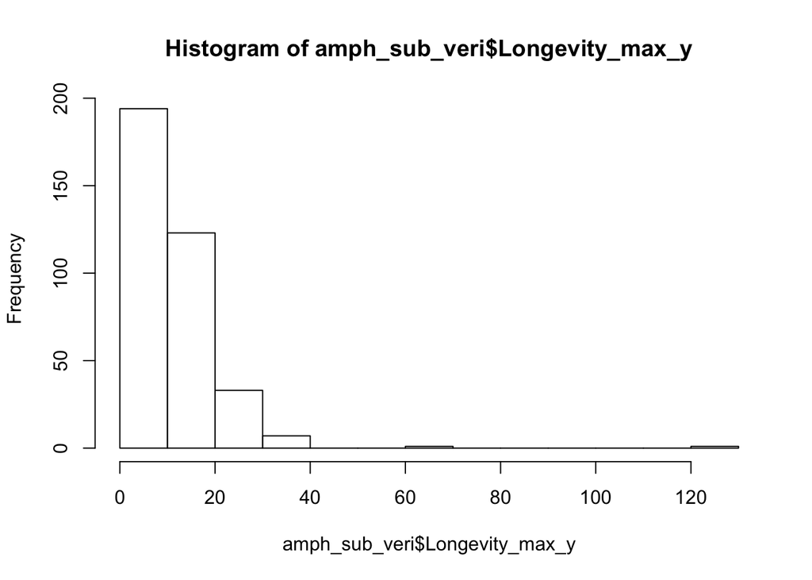

```r
hist(amph_sub_veri$Longevity_max_y)
```

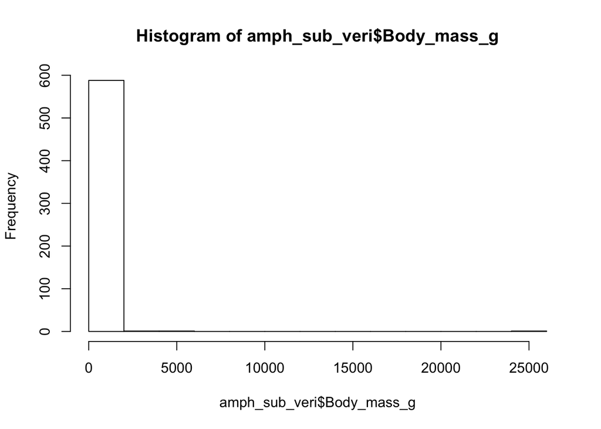

```r
hist(amph_sub_veri$Body_mass_g)
```

Şimdi de kutu grafiğinde inceleyelim:

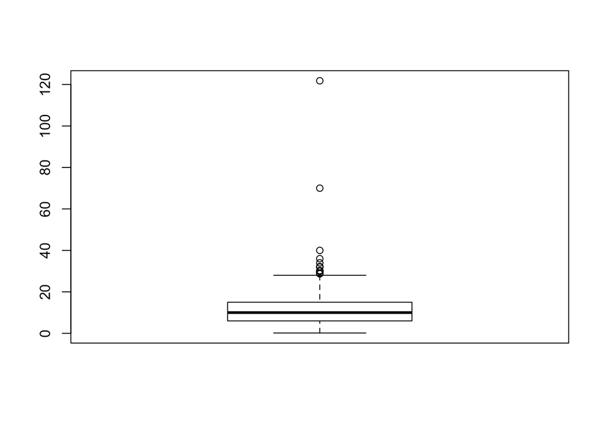

```r
boxplot(amph_sub_veri$Longevity_max_y)
```

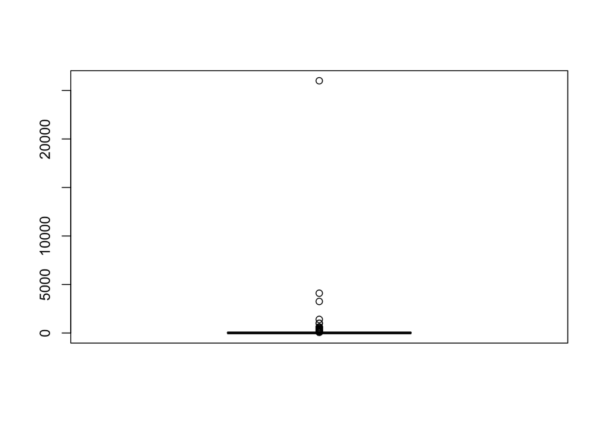

```r
boxplot(amph_sub_veri$Body_mass_g)
```

Son olarak ikisini kıyaslayalım ve ilişkilerine bakalım:

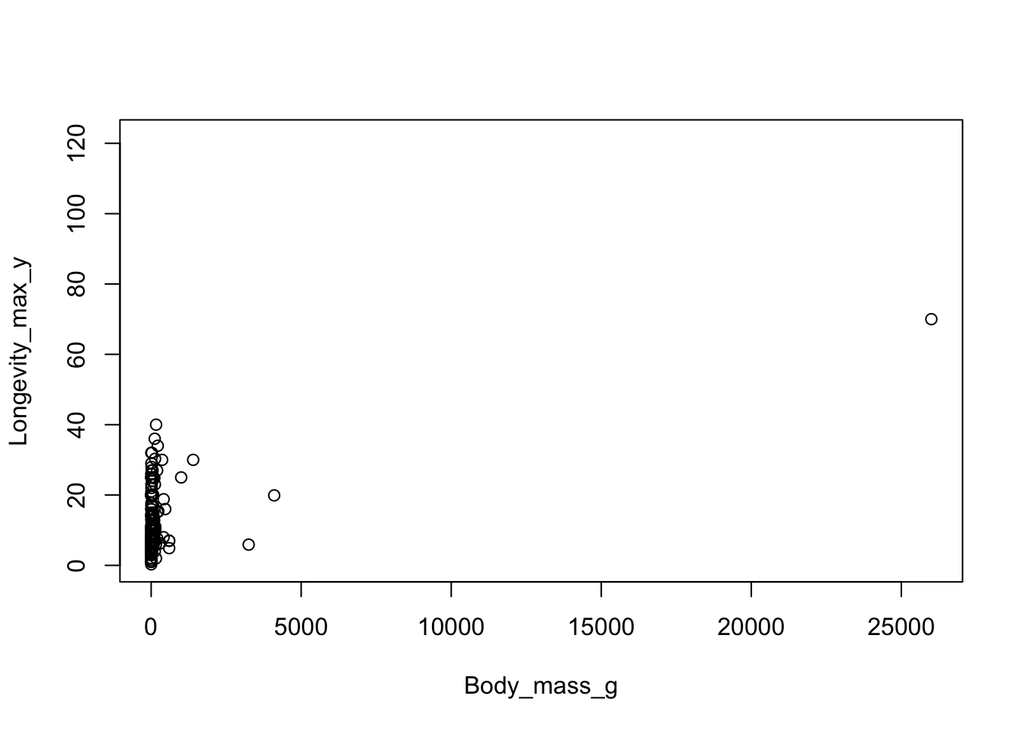

```r
plot(data=amph_sub_veri, Longevity_max_y~Body_mass_g)
```

Görüldüğü üzere oluşturulan grafikler bir anlam ifade etmemektedir. Bunun nedeni kıyaslanmak istenen verilerin farklı birimlerde olmasıdır. Örneğin yaşam ömrü sayı, vücut kütlesi de gram cinsindendir. Yorumlanabilir bir görselleştirme için bu verileri logaritmik cinsten yazabiliriz.

O zaman son denediğimiz grafiği, log versiyonda inceleyelim:

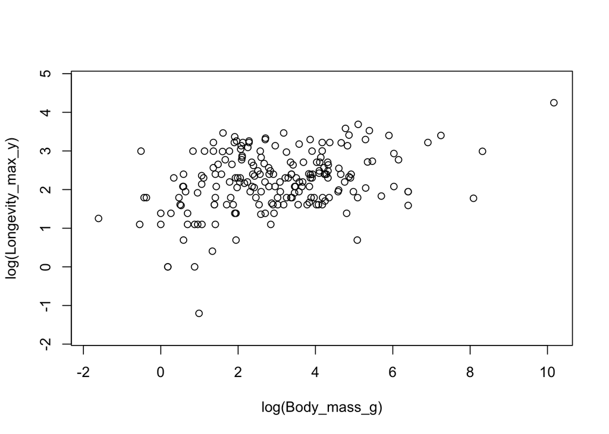

```r
plot(data=amph_sub_veri, log(Longevity_max_y)~log(Body_mass_g))
```

Artık grafiğimiz daha güzel görünüyor. Bunun yerine oluşturduğumuz alt veriyi tek tek log cinsinde tanımlamak yerine, alt veri setinin tamamını log cinsine çevirelim:

> Burada dikkat etmeniz gereken şey şu, elimizde sadece sayısal veri olduğu için bütün veri çerçevesini `log` fonksiyonu ile modifiye edebildik. Eğer elimizda karakter verileri de olsaydı, tek tek sütunları dönüştürmek durumunda kalacaktık.

```r
amph_log <- log(amph_sub_veri)
```

Şimdi sütun isimlerine bir bakalım. Görüldüğü üzere verimiz aynı kaldı, sadece değerlerin birimi değişti.

```r
colnames(amph_log)
```

```
## [1] "Longevity_max_y"         "Body_size_mm"
## [3] "Body_mass_g"             "Size_at_maturity_max_mm"
## [5] "Size_at_maturity_min_mm"
```

Log cinsindeki veri setimizin bütün grafiklerini inceleyelim:

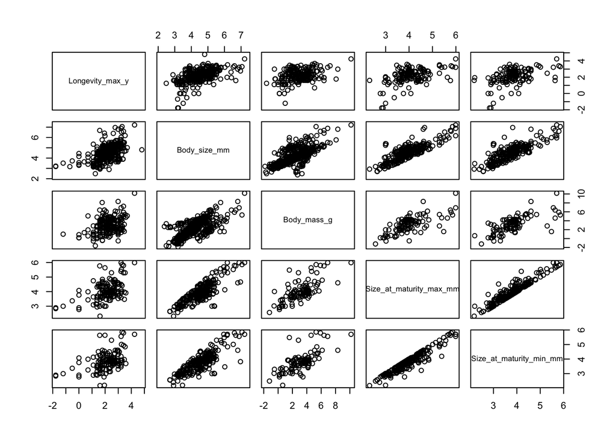

```r
plot(amph_log)
```

Şimdi de bu veri setimizde yer alan herhangi bir veriyi histogramda inceleyelim:

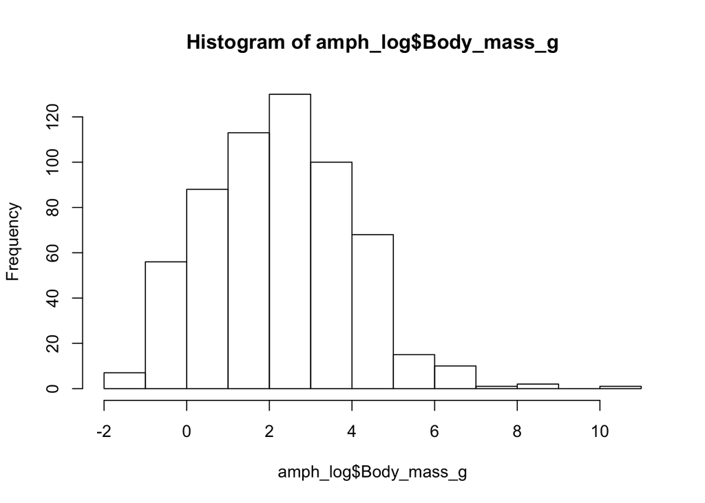

```r
hist(amph_log$Body_mass_g)
```

## 1.2 Modelleme aşaması

Veri setindeki bir veri ile model oluşturalım,

```r
model <- lm(data=amph_log, Longevity_max_y~.)
```

ve bu modeli özetleyelim:

```r
summary(model)
```

```
##
## Call:
## lm(formula = Longevity_max_y ~ ., data = amph_log)
##
## Residuals:
##     Min      1Q  Median      3Q     Max
## -2.6380 -0.3021  0.0522  0.3997  1.5397
##
## Coefficients:
##                          Estimate Std. Error t value Pr(>|t|)
## (Intercept)             -0.585827   0.563194  -1.040    0.302
## Body_size_mm             0.837676   0.194989   4.296 5.09e-05 ***
## Body_mass_g             -0.007727   0.064145  -0.120    0.904
## Size_at_maturity_max_mm  0.226719   0.302220   0.750    0.455
## Size_at_maturity_min_mm -0.531002   0.320047  -1.659    0.101
## ---
## Signif. codes:  0 '***' 0.001 '**' 0.01 '*' 0.05 '.' 0.1 ' ' 1
##
## Residual standard error: 0.6987 on 76 degrees of freedom
##   (6695 observations deleted due to missingness)
## Multiple R-squared:  0.3834, Adjusted R-squared:  0.351
## F-statistic: 11.82 on 4 and 76 DF,  p-value: 1.627e-07
```

İstersek verileri inceledikten sonra kullanılmasının anlamsız olduğunu düşündüğümüz yani birbirini etkileyen ve güçlü korelasyon gösteren verileri bir araya getirerek daha anlamlı bir model de oluşturabiliriz:

```r
model_1 <- lm(data=amph_log, Longevity_max_y~Body_mass_g*Body_size_mm + Body_size_mm)
```

Şimdi bu yeni modeli özetleyerek inceleyip, yapmaya çalıştığımız şeyin etkisini kontrol edebiliriz.

```r
summary(model_1)
```

```
##
## Call:
## lm(formula = Longevity_max_y ~ Body_mass_g * Body_size_mm + Body_size_mm,
##     data = amph_log)
##
## Residuals:
##     Min      1Q  Median      3Q     Max
## -2.7488 -0.3470  0.0092  0.3749  1.5256
##
## Coefficients:
##                          Estimate Std. Error t value Pr(>|t|)
## (Intercept)              -1.25954    0.41531  -3.033  0.00275 **
## Body_mass_g               0.17411    0.10253   1.698  0.09108 .
## Body_size_mm              0.79582    0.10223   7.785 3.94e-13 ***
## Body_mass_g:Body_size_mm -0.04612    0.01993  -2.314  0.02171 *
## ---
## Signif. codes:  0 '***' 0.001 '**' 0.01 '*' 0.05 '.' 0.1 ' ' 1
##
## Residual standard error: 0.6141 on 196 degrees of freedom
##   (6576 observations deleted due to missingness)
## Multiple R-squared:  0.3625, Adjusted R-squared:  0.3528
## F-statistic: 37.16 on 3 and 196 DF,  p-value: < 2.2e-16
```

AmphiBIO çalışması, 3 farklı takım bazında gerçekleştirilmiştir. Bu nedenle biz de veri setini takım bazında incelemek için yeni bir takım değişkeni oluşturabiliriz.

```r
amph_log$order <- amph_veri$Order
```

Şimdi bu incelemeyi görselleştirelim. Öncelikle programa ggplot2 aracını yükleyelim (`ggplot2` paketi tekrar tekrar yüklenmesin diye R kod bloğuna `eval = FALSE` opsiyonunu ekledik):

```r
install.packages("ggplot2")
```

Şimdi paketi aktifleştirelim:

```r
library(ggplot2)
```

Şimdi bu araçla, log cinsinden oluşturduğumuz veri setinin bir grubunu görselleştirelim, bunu her bir veri grubu için oluşturabiliriz:

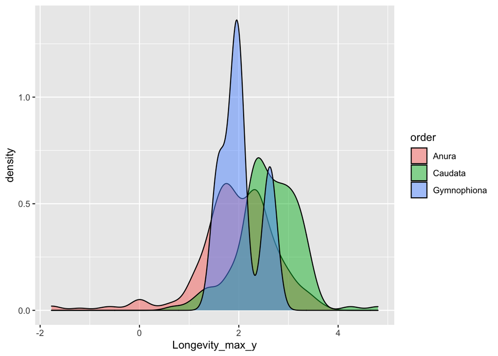

```r
ggplot(data=amph_log, aes(x=Longevity_max_y)) + geom_density(aes(fill=order), alpha = 0.5)
```

Son olarak order değişkeni ile modelleri inceleyelim ve özetlerine bakalım:

```r
model_2 <- lm(data=amph_log, Longevity_max_y~order)
```

```r
summary(model_2)
```

```
##
## Call:
## lm(formula = Longevity_max_y ~ order, data = amph_log)
##
## Residuals:
##     Min      1Q  Median      3Q     Max
## -3.7214 -0.3400 -0.0035  0.4485  2.2079
##
## Coefficients:
##                  Estimate Std. Error t value Pr(>|t|)
## (Intercept)       1.94940    0.04987  39.091  < 2e-16 ***
## orderCaudata      0.64507    0.08209   7.858 4.68e-14 ***
## orderGymnophiona  0.08752    0.37650   0.232    0.816
## ---
## Signif. codes:  0 '***' 0.001 '**' 0.01 '*' 0.05 '.' 0.1 ' ' 1
##
## Residual standard error: 0.7464 on 356 degrees of freedom
##   (6417 observations deleted due to missingness)
## Multiple R-squared:  0.1481, Adjusted R-squared:  0.1434
## F-statistic: 30.95 on 2 and 356 DF,  p-value: 4.036e-13
```

```r
model_3 <- lm(data=amph_log, Longevity_max_y~Body_mass_g * Body_size_mm + Body_size_mm + order)
```

```r
summary(model_3)
```

```
##
## Call:
## lm(formula = Longevity_max_y ~ Body_mass_g * Body_size_mm + Body_size_mm +
##     order, data = amph_log)
##
## Residuals:
##      Min       1Q   Median       3Q      Max
## -2.72387 -0.36207  0.01633  0.33894  1.58416
##
## Coefficients:
##                          Estimate Std. Error t value Pr(>|t|)
## (Intercept)              -0.25968    0.58087  -0.447  0.65533
## Body_mass_g               0.21484    0.11000   1.953  0.05225 .
## Body_size_mm              0.47821    0.16608   2.879  0.00443 **
## orderCaudata              0.46361    0.18185   2.549  0.01157 *
## orderGymnophiona         -1.02195    0.40728  -2.509  0.01292 *
## Body_mass_g:Body_size_mm -0.03192    0.01931  -1.653  0.09991 .
## ---
## Signif. codes:  0 '***' 0.001 '**' 0.01 '*' 0.05 '.' 0.1 ' ' 1
##
## Residual standard error: 0.5828 on 194 degrees of freedom
##   (6576 observations deleted due to missingness)
## Multiple R-squared:  0.4317, Adjusted R-squared:  0.4171
## F-statistic: 29.48 on 5 and 194 DF,  p-value: < 2.2e-16
```